# **JAPAN HOUSEHOLD SPENDING 2000-2017 : A STRUCTURAL STORY**

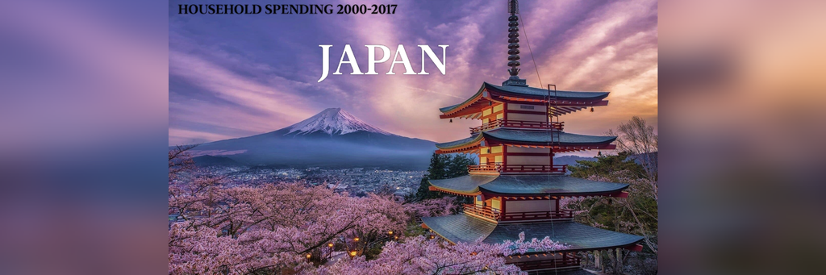

## **EXPLANATORY DATA ANALYSIS PIPELINE**

**Dataset Link:** [(https://www.stat.go.jp/english/data/kakei/156time.html]

**Source:** e-Stat — Statistics of Japan, Statistics Bureau, Ministry of Internal Affairs and Communications

**File Name:** 18-01-an.xls

### **Module : M512B DATA VISUALISATION AND COMMUNICATION**

### **CREATOR : ASHISH TIWARI (GH1045433)**

## **CHAPTER 1 - WHEN DATA SPEAKS : THE EMPIRE RISES**

**UNDERSTANDING BUSINESS AND DATA VIZUALIZATION CONTEXT**

### **1. "THE AUDIENCE I CATER" -**

So this analysis is created for the **""SENIOR STRATEGY & MARKETING EXECUTIVE" at MNC's like(FMCG, healthcare, retail etc.)** so that they can have some real amd serious strategy mapping if they think of penetrating markets in JAPAN or allocating resorce over there.

### **2. WHAT MY AUDIENCE GETS THROUGH THIS ANALYSIS-**

My analysis challenges the assumption which is being carried through past decades that JAPAN is an **"HOMOGENOUS MARKET"** and it's done as

- The contraction and growth in the Japanese household spending in over 18 years
- which expense categories signal the OT part of SWOT (Opportunities and Threats)
- And how the demographic and economic shocks reshaped the consuption structure.

### **3. SO WHAT'S MY PUNCHLINE -**

My note-book potrays **one overarching story**:

**JAPAN'S CONSUMPTION ENGINE IS QUIETLY RESTRUCTURING — AND MOST COMPANIES ARE STILL USING AN OUTDATED MAP**

## **CHAPTER 2 - THE BEDROCK OF POWER : GATHERING THE RAW ASSETS**

**SETTING UP AND IMPORTING LIBRARIES**

Here I import the libraries as usual also in the Initial step only I implemented the general "clutter removal" and use color sparing taught in module so that the colours in vizualization further already set a tone like specific tone of RED to demonstrate to denote strong downfall, green to show positive,orange as warning mid point, blue as second most important insight vie etc.

```python
import pandas as pd
import numpy as np
import matplotlib.pyplot as plt
import matplotlib.ticker as mticker
import matplotlib.patches as mpatches
import matplotlib.colors as mcolors
from matplotlib.lines import Line2D
from matplotlib.gridspec import GridSpec
import warnings
warnings.filterwarnings('ignore')

plt.rcParams.update({
    'font.family':       'DejaVu Sans',
    'font.size':         11,
    'axes.spines.top':   False,
    'axes.spines.right': False,
    'axes.grid':         False,
    'figure.dpi':        150,
    'axes.labelcolor':   '#444444',
    'xtick.color':       '#666666',
    'ytick.color':       '#666666',
    'text.color':        '#222222',
    'figure.facecolor':  'white',
    'axes.facecolor':    'white',
})

ACCENT = '#C0392B'
BLUE   = '#2C5F8A'
MUTED  = '#CCCCCC'
DARK   = '#1A1A2E'
GREEN  = '#27AE60'
ORANGE = '#E67E22'
PURPLE = '#7D3C98'

print("Libraries loaded")
```

```
Libraries loaded
```

## **CHAPTER 3 - MAPPING THE REALM : SURVEYING THE DIGITAL TERRAIN**

**DATA UNDERSTANDING AND EXPLORATION**

```python
import os

XLS_PATH = '/content/18-01-an.xls'

if os.path.exists(XLS_PATH):
    raw = pd.read_excel(XLS_PATH, engine='xlrd', header=None)
    print("File loaded:", raw.shape)
else:
    raise FileNotFoundError("FILES NOT THERE ASH")
```

```
File loaded: (33, 129)
```

```python
print("=" * 50)
print("  DATA QUALITY REPORT  -  18-01-an.xls")
print("=" * 50)
print("  Shape:           {} rows x {} cols".format(raw.shape[0], raw.shape[1]))
print("  Survey type:     Two-or-more-person households")
print("  Time range:      2000 to 2017 (18 years)")
print("  Expenditure cols: 127 categories")
print("  Units:           Average monthly expenditure per household (JPY)")
print()
print("  Quality issues identified:")
issues = [
    ("Multi-row Japanese/English headers", "Rows 5-11; English labels in row 10"),
    ("Year column format",                 "Col 1 = Gregorian year (2000-2017)"),
    ("Wide format",                        "Each column = one expenditure category"),
    ("Mixed metadata rows",                "Rows 0-11 = headers/metadata, rows 12-29 = data"),
    ("Footnote rows",                      "Rows 31-32 = notes; excluded from analysis"),
]
for issue, fix in issues:
    print("  [{}]".format(issue))
    print("    Resolution: {}".format(fix))
print("=" * 60)
```

```
==================================================
  DATA QUALITY REPORT  -  18-01-an.xls
==================================================
  Shape:           33 rows x 129 cols
  Survey type:     Two-or-more-person households
  Time range:      2000 to 2017 (18 years)
  Expenditure cols: 127 categories
  Units:           Average monthly expenditure per household (JPY)

  Quality issues identified:
  [Multi-row Japanese/English headers]
    Resolution: Rows 5-11; English labels in row 10
  [Year column format]
    Resolution: Col 1 = Gregorian year (2000-2017)
  [Wide format]
    Resolution: Each column = one expenditure category
  [Mixed metadata rows]
    Resolution: Rows 0-11 = headers/metadata, rows 12-29 = data
  [Footnote rows]
    Resolution: Rows 31-32 = notes; excluded from analysis
============================================================
```

```python
headers_raw = raw.iloc[10].tolist()
data = raw.iloc[12:30].copy()
data.columns = range(len(data.columns))

years = data[1].astype(int).tolist()

col_map = {
    1:   'Year',
    6:   'Total',
    7:   'Food',
    13:  'Fish & Shellfish',
    18:  'Meat',
    25:  'Vegetables',
    30:  'Fruits',
    36:  'Cakes & Candies',
    37:  'Cooked Food',
    44:  'Alcoholic Beverages',
    45:  'Dining Out',
    48:  'Housing',
    53:  'Fuel & Light',
    58:  'Furniture',
    68:  'Clothing & Footwear',
    86:  'Medical Care',
    91:  'Transport & Comms',
    98:  'Education',
    102: 'Culture & Recreation',
    111: 'Other Consumption',
    128: 'Engel Coefficient',
}

df = data[list(col_map.keys())].copy()
df.columns = list(col_map.values())
df['Year'] = df['Year'].astype(int)
df = df.set_index('Year')

for col in df.columns:
    df[col] = pd.to_numeric(df[col], errors='coerce')

TOP_CATS = ['Food','Housing','Fuel & Light','Furniture',
            'Clothing & Footwear','Medical Care',
            'Transport & Comms','Education',
            'Culture & Recreation','Other Consumption']

df_top = df[TOP_CATS]

print("Clean dataset ready")
print("Years: {} to {}".format(df.index.min(), df.index.max()))
print("Categories: {}".format(len(TOP_CATS)))
print()
print(df_top.to_string())
```

```
Clean dataset ready
Years: 2000 to 2017
Categories: 10

       Food  Housing  Fuel & Light  Furniture  Clothing & Footwear  Medical Care  Transport & Comms  Education  Culture & Recreation  Other Consumption
Year
2000  73954    20522         21628      11024                16140         11354              36386      13921                 32036              80364
2001  71770    19679         21529      11144                15057         11591              36507      12929                 31299              77551
2002  71210    19957         21171      10509                14477         11600              36595      12852                 30760              76821
2003  69910    20027         20922      10329                13868         12441              37417      13009                 29915              74002
2004  69640    19230         21012       9952                13396         12231              38981      13229                 30883              74422
2005  68699    19254         21492      10047                13339         13020              38717      12475                 30729              72759
2006  68111    18115         22278       9734                12776         12787              37864      12650                 30040              70588
2007  68536    17934         21768       9706                12933         13107              38075      12748                 30976              71999
2008  69001    16897         22762       9984                12523         12649              39147      12727                 31372              69869
2009  68322    17024         21685       9975                11994         13016              38070      12909                 31274              67469
2010  67563    18179         21951      10266                11499         12515              38965      11734                 31879              65695
2011  66904    18874         21954      10070                11382         12691              36509      11630                 29063              63889
2012  67275    18231         22815      10122                11453         12777              40089      11610                 28483              63316
2013  68604    18262         23240      10325                11756         12763              41433      11539                 28959              63573
2014  69926    17919         23799      10633                11983         12838              41912      10936                 28942              62305
2015  71844    17931         23197      10458                11363         12663              40238      10995                 28314              60371
2016  72934    16679         21177      10329                10878         12888              39054      11310                 28159              58780
2017  72866    16555         21535      10560                10806         12873              39691      11062                 27958              59120
```

### **DATA QUALITY ISSUES & RESOLUTIONS**

| Issue | Resolution |
| --- | --- |
| Multi-row Japanese/English headers (rows 0–11) | Located English labels in row 10; mapped by column index |
| Wide format (127 columns) | Selected 10 top-level categories + key sub-categories by column index |
| Footnote rows at bottom | Excluded rows 30–32 from data extraction |
| Japanese Era year in col 0 (平成12年 etc.) | Used col 1 (Gregorian year) as the time index |
| Mixed numeric/string in cells | `pd.to_numeric(..., errors='coerce')` applied to all value columns |

## **CHAPTER 4 : THE EIGHT CROWNS OF CLARITY : ILLUMINATING THE PATH TO CONQUEST**

**EXPLANATORY DATA VISUALIZATIONS- 8 KEY INSIGHTS**

### **Insight 1: Japan's Total Household Spending Has Never Recovered From Two Decisive Shocks**

**Business Importance:** The total consumption envelope sets the ceiling for every category strategy. Over 18 years, Japan's two-or-more-person households saw monthly spending fall from ¥317k to ¥283k — a ¥34k decline (11%) in nominal terms, implying a significantly steeper real decline when adjusted for inflation. Two events carved permanent notches: the Global Financial Crisis (2008) and the consumption tax hike (2014). Companies treating Japan as a stable growth market are anchored to a map that no longer exists.

**Design Choices — Course Principles Applied:**

- **Context:** C-suite investment decision-makers sizing total Japan market potential
- **Chart type:** Annotated line chart — the optimal display for time-series with narrative events; each annotation answers "why did it drop here?"
- **Eliminate clutter:** No gridlines, no right/top spines, no legend box; y-axis label replaced by direct formatter
- **Draw attention:** Two shocks marked with dashed verticals; post-2014 segment highlighted in red to separate the "new normal"
- **Gestalt — Continuity:** Single line guides the eye through 18 years without interruption
- **Preattentive:** Red vs. grey segment colour contrast is processed before reading any labels
- **Story:** Title IS the insight, not "Total Expenditure 2000–2017"

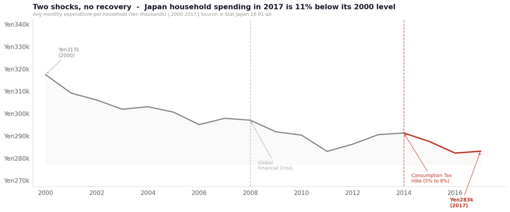

```python
fig, ax = plt.subplots(figsize=(13, 5.5))

yrs   = df.index.tolist()
total = df['Total'].values / 1000

ax.plot(yrs[:9],  total[:9],  color='#888888', linewidth=2.2, zorder=3)
ax.plot(yrs[8:15],total[8:15],color='#888888', linewidth=2.2, zorder=3)
ax.plot(yrs[14:], total[14:], color=ACCENT,    linewidth=2.5, zorder=4)
ax.fill_between(yrs, total, total.min()-5, alpha=0.04, color='#888888')

shocks = {
    2008: ("Global\nFinancial Crisis", -18),
    2014: ("Consumption Tax\nHike (5% to 8%)", -18),
}
for yr, (label, yoff) in shocks.items():
    idx = yrs.index(yr)
    c = ACCENT if yr == 2014 else '#AAAAAA'
    ax.axvline(yr, color=c, linewidth=1.2, linestyle='--', alpha=0.7, zorder=2)
    ax.annotate(label, xy=(yr, total[idx]),
                xytext=(yr+0.3, total[idx]+yoff),
                fontsize=8.5, color=c, va='top', ha='left',
                arrowprops=dict(arrowstyle='->', color=c, lw=0.8))

ax.annotate("Yen{:.0f}k\n(2000)".format(total[0]),
            xy=(2000, total[0]), xytext=(2000.5, total[0]+8),
            fontsize=9, color='#888888',
            arrowprops=dict(arrowstyle='->', color='#AAAAAA', lw=0.8))
ax.annotate("Yen{:.0f}k\n(2017)".format(total[-1]),
            xy=(2017, total[-1]), xytext=(2015.8, total[-1]-25),
            fontsize=9, color=ACCENT, fontweight='bold',
            arrowprops=dict(arrowstyle='->', color=ACCENT, lw=0.8))

ax.set_xlim(1999.5, 2018)
ax.set_ylim(total.min()-15, total.max()+25)
ax.set_xticks(range(2000, 2018, 2))
ax.yaxis.set_major_formatter(mticker.FuncFormatter(lambda x,_: "Yen{:.0f}k".format(x)))
ax.spines['left'].set_color('#DDDDDD')
ax.spines['bottom'].set_color('#DDDDDD')
ax.tick_params(length=0, pad=6)

ax.set_title("Two shocks, no recovery  -  Japan household spending in 2017 is 11% below its 2000 level",
             fontsize=13, fontweight='bold', color=DARK, pad=18, loc='left')
ax.text(0, 1.02, "Avg monthly expenditure per household (Yen thousands) | 2000-2017 | Source: e-Stat Japan 18-01-an",
        transform=ax.transAxes, fontsize=8.5, color='#999999')

plt.tight_layout()
plt.savefig('insight1_annotated_line.png', dpi=150, bbox_inches='tight')
plt.show()
```